# Measures of Variability

# Introduction

In a previous article, we discussed the properties of the *mean*, *median*, and *mode* for a given set of real numbers $\{x_j\}_{j=1}^n$.

We say that these three quantities (the mean, median, and mode) measure the *central tendency* of the set of real numbers $\{x_j\}_{j=1}^n$ that we have been given.

However, it is often the case that the “center” of a set of numbers, by itself, will not provide an adequate summary of the set as a whole.

Indeed, consider the sets of numbers

$$X_1 = \{1,2,3,4,5,6,7,8,9\}$$

We could construct a *histogram* to visualize $X_1$. When we do this, it might look something like this:

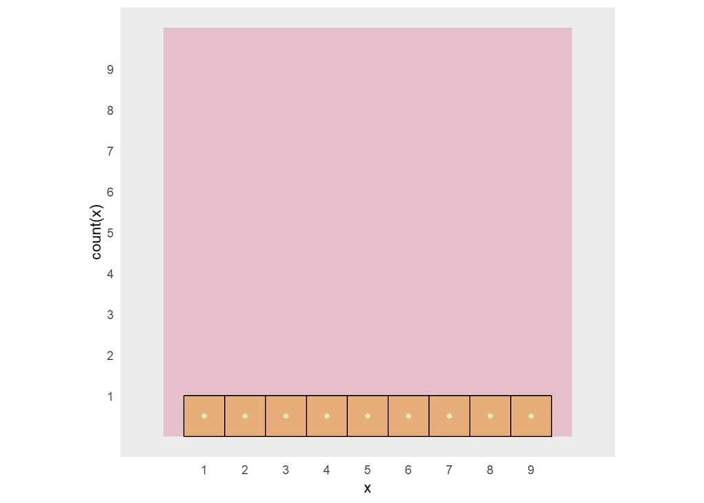

Now, contrast the set of numbers above with the set below:

$$X_2 = \{5,5,5,5,5,5,5,5,5\}$$

A histogram for $X_2$ might look something like this:

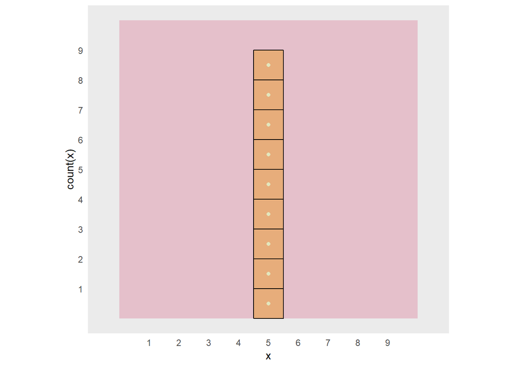

Note that the mean of $X_1$ equals the mean of $X_2$:

$$\frac{ \sum_{j=1}^9 j }{9} = \frac{9 \times 5 }{9} =5.$$

However, it is easy to see that $X_1$ is more “spread out” than $X_2$.

In fact, $X_2$ is not spread out at all!

In other words, the data for $X_1$ exhibits *variability* while the data for $X_2$ does not.

The concept of variability is what we will discuss in this article.

Before we begin, let’s talk about different ways to visualize variability in a dataset.

# Visualizing Variation

In the introduction, we used *histograms* to visualize our data and to introduce the concept of variability.

However, there are other ways to “see” variation in a data set.

Suppose that we measure the heights of sixteen flowers. We measure the heights in inches, and these are our results:

| id | height |
| --- | --- |
| 1 | 5 |
| 2 | 4 |
| 3 | 3 |
| 4 | 5 |
| 5 | 6 |
| 6 | 6 |
| 7 | 7 |
| 8 | 6 |
| 9 | 9 |
| 10 | 7 |
| 11 | 8 |
| 12 | 6 |
| 13 | 4 |
| 14 | 8 |
| 15 | 7 |
| 16 | 5 |

Now, we *could* make a histogram for the variable *height*.

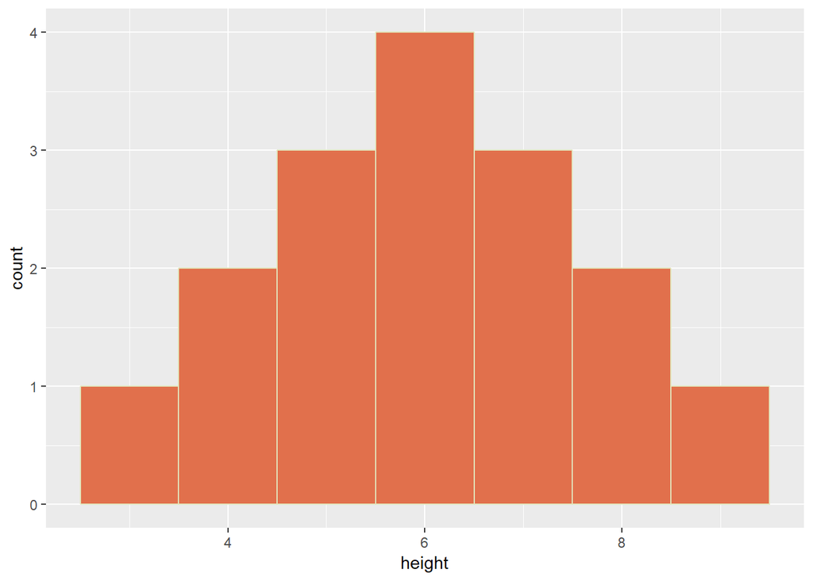

However, we could also use a “bar plot” to visualize the height of each flower as follows:

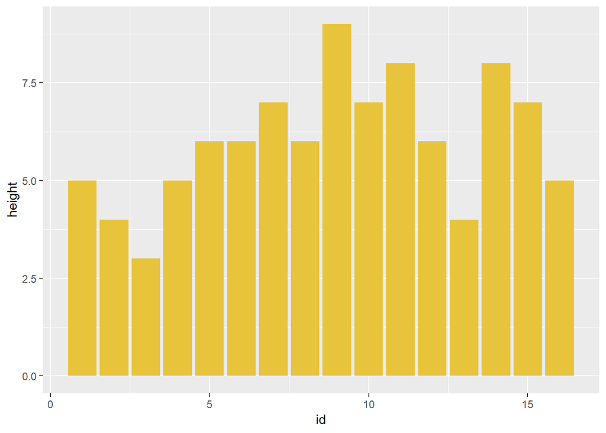

Note that one advantage of the bar plot is that we can actually “see” the height of our flowers vary as our eyes move across the plot.

Often times, we will be interested in examining how our data varies with respect to the mean of the data.

In the plot below, we have drawn a horizontal dashed, red line with a $y$-intercept of equal to the mean of the heights ($y=6$):

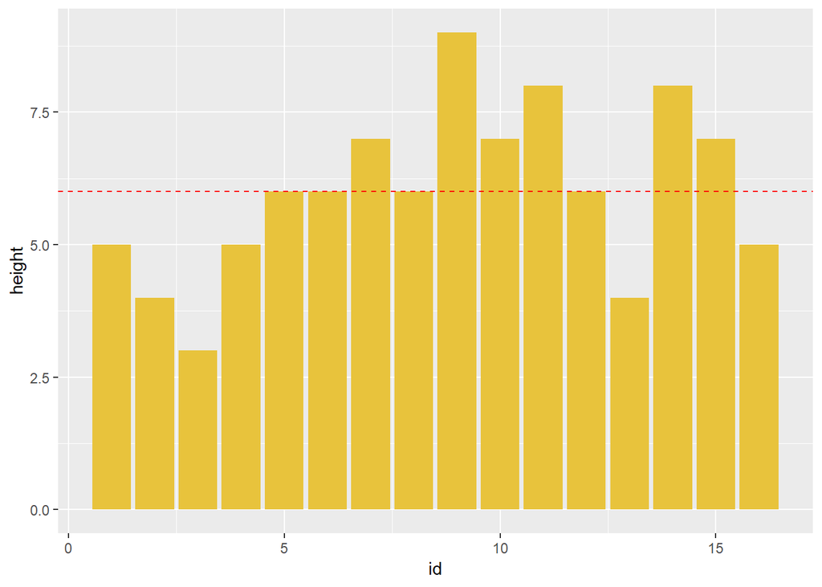

This illustrates why it is that we can think of the mean as a measurement of the “center” of our data. As our eyes read the plot from left to right, the heights of the bars vary. However, the variations are somehow “centered” about the mean. Some are above and some are below, but they all seem to even out in the end.

In our discussion below, we will use histograms, bar plots, and other means of visualizing variability.

# Order Statistics

## Range

One of the easiest and most straightforward ways to measure the variability of a set of numbers is by calculating its *range*.

The range of a set of numbers is simply the value you get when you subtract the smallest value from the largest value.

For example, consider the following information from the “mtcars” dataset included with R:

| id | mpg | cyl |
| --- | --- | --- |
| 1 | 21.0 | 6 |
| 2 | 21.0 | 6 |
| 3 | 22.8 | 4 |
| 4 | 21.4 | 6 |
| 5 | 18.7 | 8 |
| 6 | 18.1 | 6 |
| 7 | 14.3 | 8 |
| 8 | 24.4 | 4 |
| 9 | 22.8 | 4 |
| 10 | 19.2 | 6 |
| 11 | 17.8 | 6 |
| 12 | 16.4 | 8 |
| 13 | 17.3 | 8 |
| 14 | 15.2 | 8 |
| 15 | 10.4 | 8 |
| 16 | 10.4 | 8 |
| 17 | 14.7 | 8 |
| 18 | 32.4 | 4 |
| 19 | 30.4 | 4 |
| 20 | 33.9 | 4 |
| 21 | 21.5 | 4 |
| 22 | 15.5 | 8 |
| 23 | 15.2 | 8 |
| 24 | 13.3 | 8 |
| 25 | 19.2 | 8 |
| 26 | 27.3 | 4 |
| 27 | 26.0 | 4 |
| 28 | 30.4 | 4 |
| 29 | 15.8 | 8 |
| 30 | 19.7 | 6 |
| 31 | 15.0 | 8 |
| 32 | 21.4 | 4 |

If we focus in on the “mpg” variable, then we can see that the largest value (33.9) corresponds to id = 20. Meanwhile, the smallest value (10.4) is a tie between id =15 and id = 16.

At any rate, the range of the mpg variable is calculated by finding the difference between these two values:

$$\text{range}_{\text{mpg}} = \text{max}_{\text{mpg}}- \text{min}_{\text{mpg}} = 33.9 -10.4 = 23.5$$

Here is a visualization of our data set.

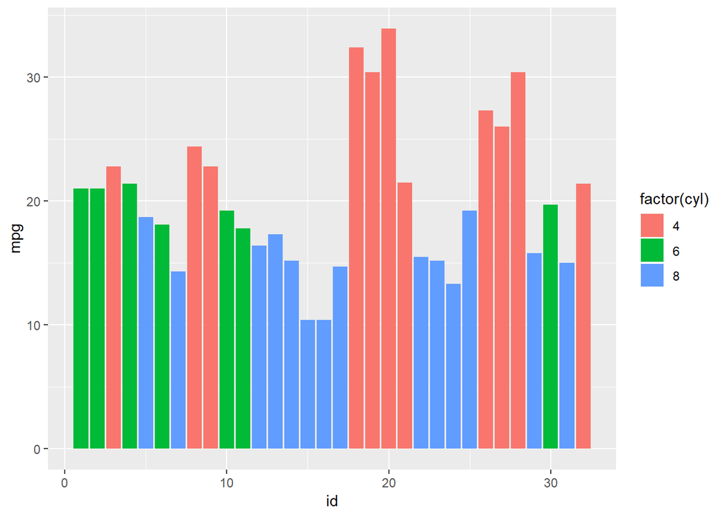

We can visualize the range by zeroing in on the largest and smallest values.

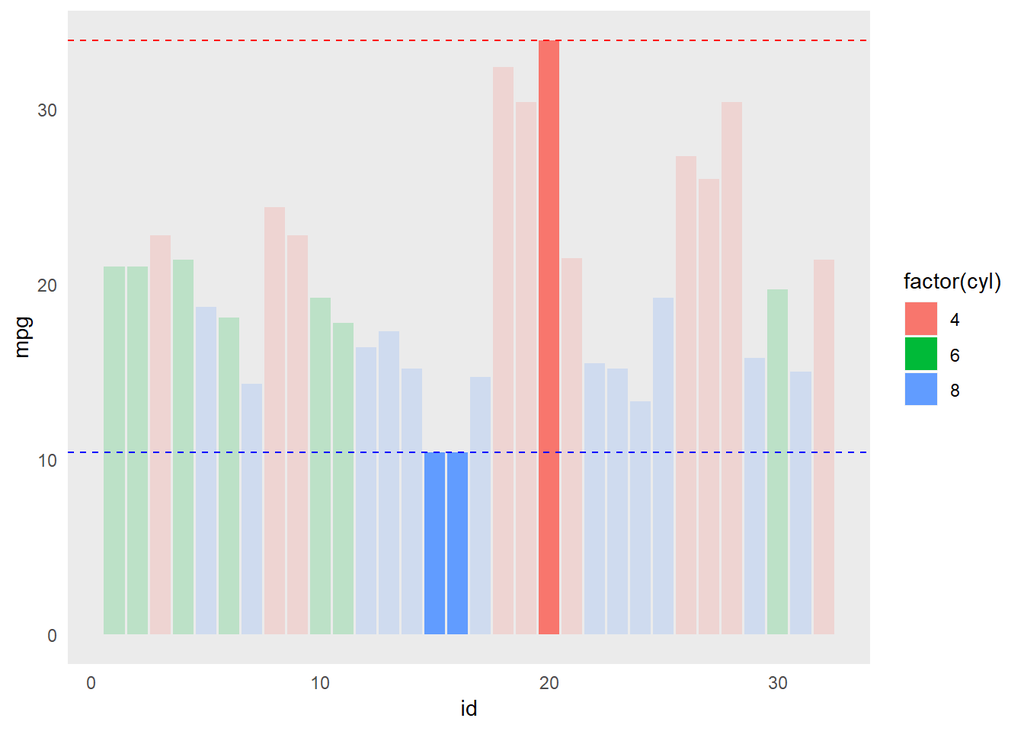

The difference between the height of the largest bar and the height of the smallest bar equals the range. In other words, the range is the distance between the two dashed lines in the plot above.

## Interquartile Range

Let’s turn now to the “iris” dataset included with R.

In particular, let’s look at the “Petal.Length” variable.

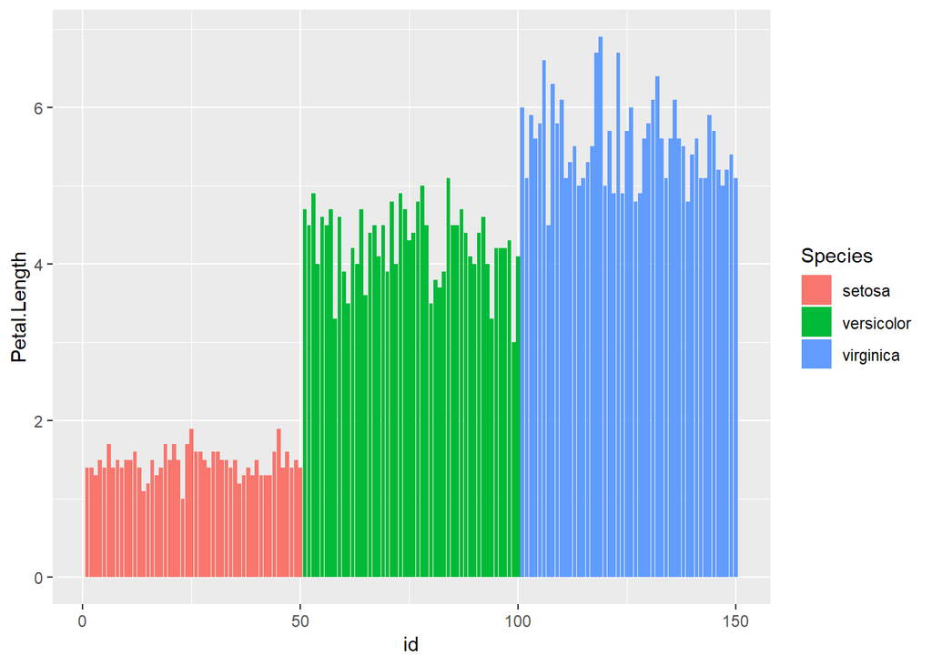

In the plot above, we can see how the “Petal.Length” varies across all of the elements in our dataset.

Let’s go ahead and zoom in on the “virginica species.”

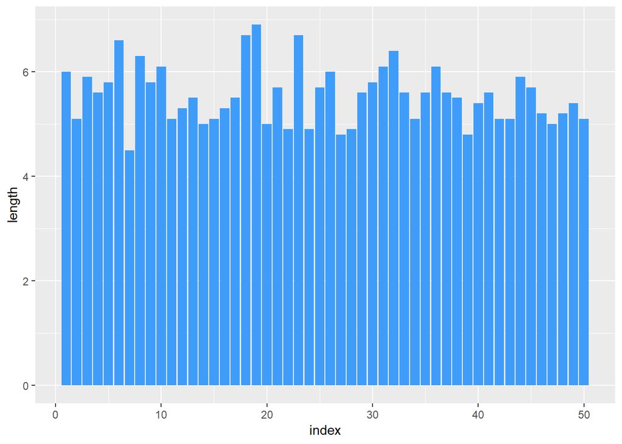

Now, let’s arrange the lengths of these flowers from smallest to largest.

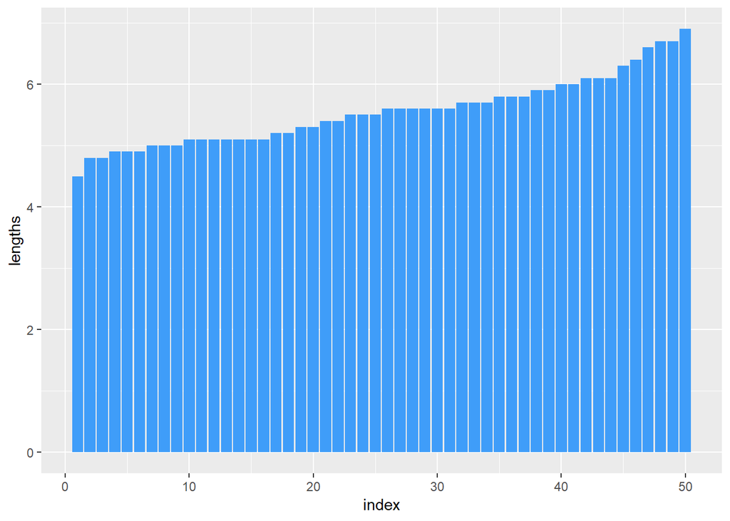

Now, let’s divide our sorted data set into four groups.

We do this in the following manner. We make it so that

- the first 25% of our sorted dataset is in the first group,
- the first 50% of our sorted dataset is in the union of the first and second groups, and
- the first 75% of our sorted dataset is in the union of the first, second, and third groups.

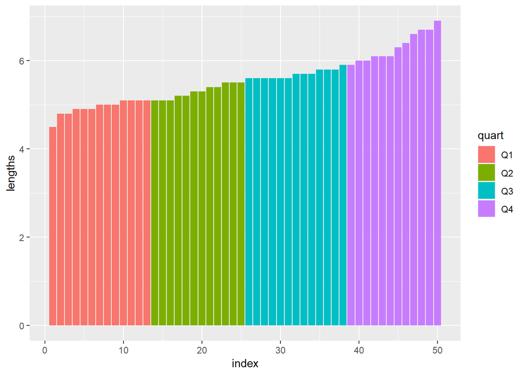

In the plot above, the $y$ value that marks the division between groups one and two is called the *lower quantile*.

Similarly, the $y$ value that marks the division between groups three and four is called the *upper quantile*.

We draw our plot again, indicating

- the lower quantile (5.1) with a dashed, red line and
- the upper quantile (5.9) with a dashed, blue line.

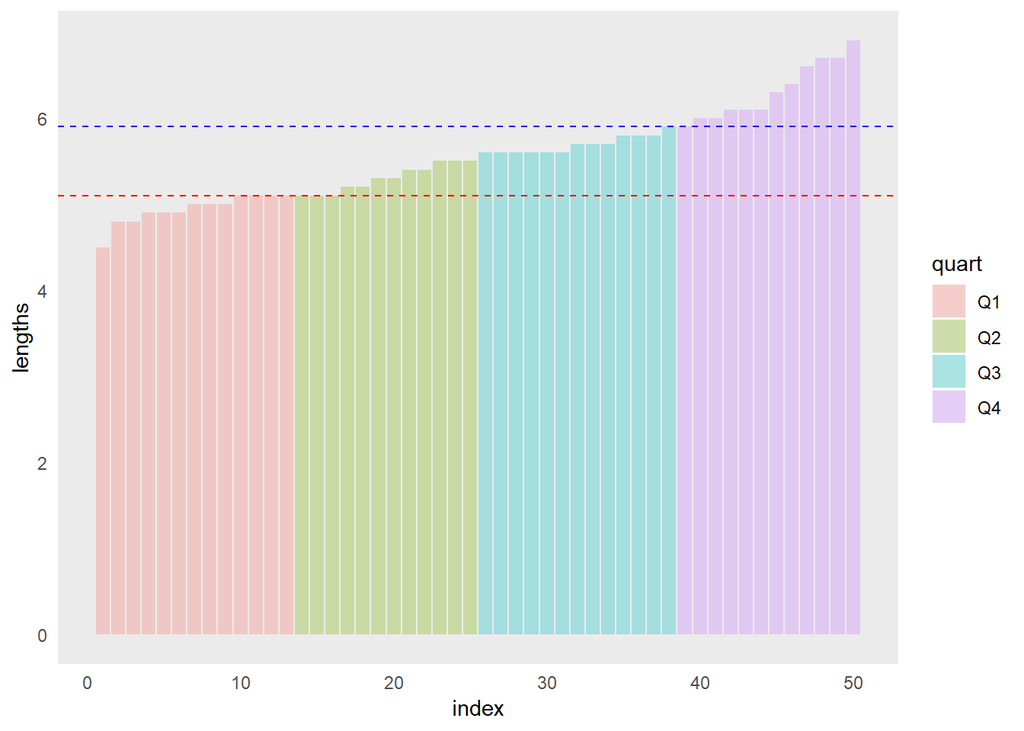

The interquartile range (IQR) is the distance between the two lines above.

This equals the length of the line segment shown below.

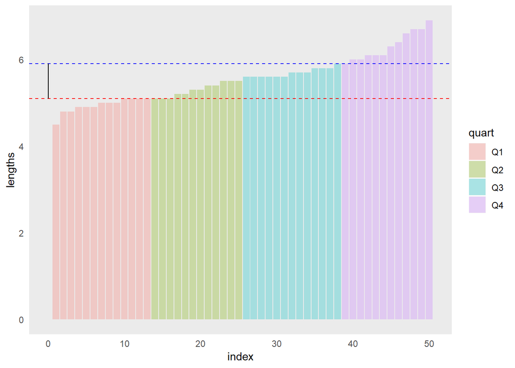

In other words, the interquartile range is the difference between the upper quantile and the lower quantile.